# Lung primary cells RNAseq for Nick : refining for paper

Marion Hardy

2024-05-22

# Introduction

Kenneth did RNAseq on lung primary cells.

That data was aligned by the genome center, we have the preliminary reports:

- qc_report_genome_center.html : quality control of the alignment of the data
- initial_report_genome_center: describes each sample (used for annotations) and did a basic PCA + how many genes are differentially expressed when comparing conditions.

We want to know what pathways/processes changed after different treatments. We are specifically interested in seeing why cytokines (IL5, IL13, ILxx) induce SPREADS but do not when coupled with pitavastatin.

So ultimately, what is pitavastatin suppressing?

# What is in common and what is specific to each conditions?

## Venn diagram

Compare all the differentially expressed genes vs control to each other. This plot allows us to know which genes can be found to be perturbed vs control in all conditions as well as those that are specific to one condition or another.

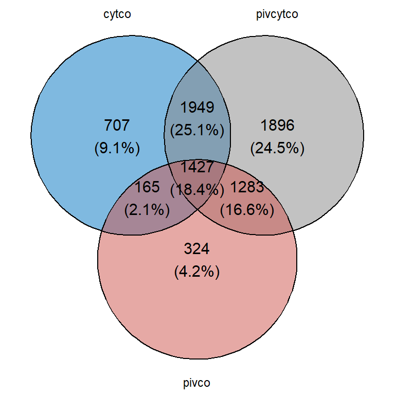

## UP in cytokine and DOWN in Cyt + Pit

| ensembl | log2FoldChange | protID | gene | description | padj |
| --- | --- | --- | --- | --- | --- |
| ENSG00000127324 | 0.7722139 | P19075 | TSPAN8 | tetraspanin 8 [Source:HGNC Symbol;Acc:HGNC:11855] | 0.0000034 |
| ENSG00000204389 | 0.4229179 | P0DMV8 | HSPA1A | heat shock protein family A (Hsp70) member 1A [Source:HGNC Symbol;Acc:HGNC:5232] | 0.0000052 |
| ENSG00000204388 | 0.3292206 | P0DMV9 | HSPA1B | heat shock protein family A (Hsp70) member 1B [Source:HGNC Symbol;Acc:HGNC:5233] | 0.0001072 |
| ENSG00000111684 | 0.3140090 | Q6P1A2 | LPCAT3 | lysophosphatidylcholine acyltransferase 3 [Source:HGNC Symbol;Acc:HGNC:30244] | 0.0004849 |
| ENSG00000105655 | 0.2977650 | J3QRY0 | ISYNA1 | inositol-3-phosphate synthase 1 [Source:HGNC Symbol;Acc:HGNC:29821] | 0.0299998 |
| ENSG00000143416 | 0.2839050 | F8WBA9 | SELENBP1 | selenium binding protein 1 [Source:HGNC Symbol;Acc:HGNC:10719] | 0.0003274 |
| ENSG00000174844 | 0.2440909 | E9PG32 | DNAH12 | dynein axonemal heavy chain 12 [Source:HGNC Symbol;Acc:HGNC:2943] | 0.0183313 |
| ENSG00000120885 | 0.2417066 | E5RG36 | CLU | clusterin [Source:HGNC Symbol;Acc:HGNC:2095] | 0.0013359 |
| ENSG00000165698 | 0.2294103 | Q96E40 | SPACA9 | sperm acrosome associated 9 [Source:HGNC Symbol;Acc:HGNC:1367] | 0.0046370 |
| ENSG00000112584 | 0.1857274 | Q96EK7 | FAM120B | family with sequence similarity 120B [Source:HGNC Symbol;Acc:HGNC:21109] | 0.0147811 |
| ENSG00000188229 | 0.1841673 | P68371 | TUBB4B | tubulin beta 4B class IVb [Source:HGNC Symbol;Acc:HGNC:20771] | 0.0120342 |

### Heatmap

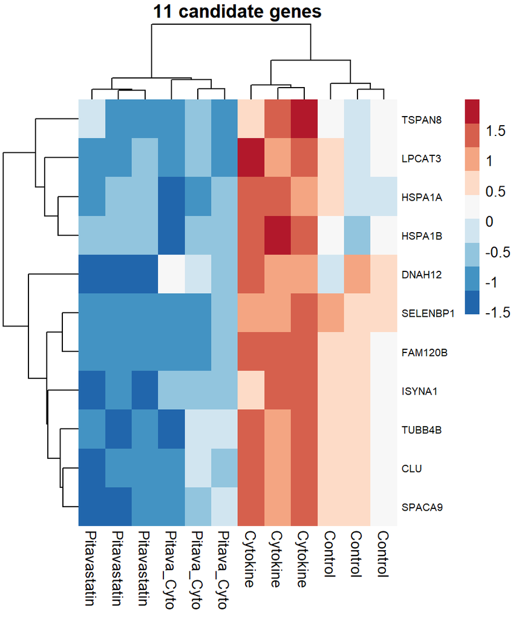

### Enrichment analysis (Over-representation analysis)

#### GOBP

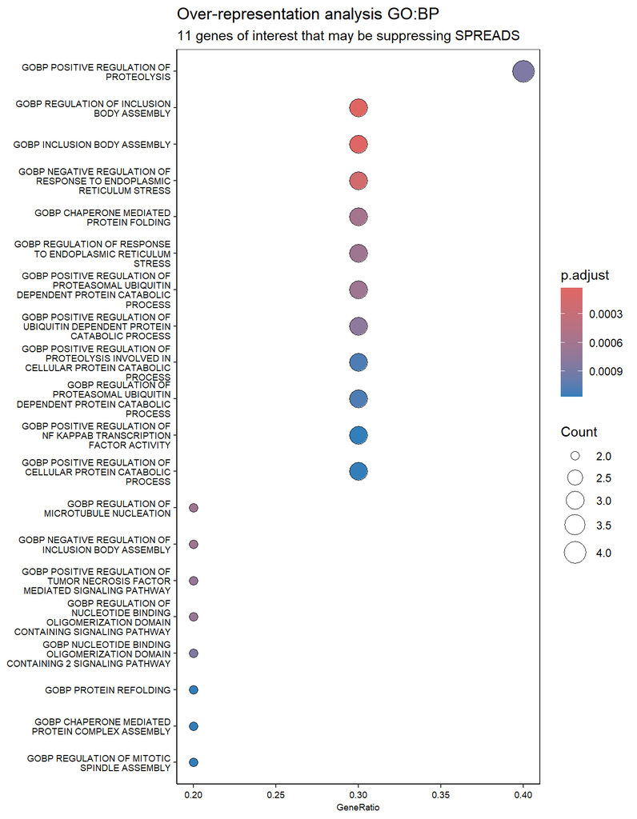

#### GOMF

[figure not shown]

## UP in cytokine and UNCHANGED in Cyt + Piv

There are 377 such genes.

| ensembl | log2FoldChange | protID | gene | description | padj |
| --- | --- | --- | --- | --- | --- |
| ENSG00000234965 | 2.9034690 | B8ZZ34 | SHISA8 | shisa family member 8 [Source:HGNC Symbol;Acc:HGNC:18351] | 0.0000002 |
| ENSG00000146006 | 2.8039319 | O43300 | LRRTM2 | leucine rich repeat transmembrane neuronal 2 [Source:HGNC Symbol;Acc:HGNC:19409] | 0.0003391 |
| ENSG00000189419 | 2.6545030 |  | SPATA41 | spermatogenesis associated 41 [Source:HGNC Symbol;Acc:HGNC:48613] | 0.0029718 |
| ENSG00000198829 | 2.5525704 | Q9BXA5 | SUCNR1 | succinate receptor 1 [Source:HGNC Symbol;Acc:HGNC:4542] | 0.0000386 |
| ENSG00000237167 | 2.3959842 |  |  | novel transcript | 0.0003454 |
| ENSG00000187513 | 2.3313381 | P35212 | GJA4 | gap junction protein alpha 4 [Source:HGNC Symbol;Acc:HGNC:4278] | 0.0110205 |
| ENSG00000182334 | 2.2463064 | Q8WZ94 | OR5P3 | olfactory receptor family 5 subfamily P member 3 [Source:HGNC Symbol;Acc:HGNC:14784] | 0.0174610 |
| ENSG00000236700 | 2.0748350 |  | LINC01010 | long intergenic non-protein coding RNA 1010 [Source:HGNC Symbol;Acc:HGNC:48978] | 0.0199376 |
| ENSG00000044524 | 2.0700728 | C9JXA2 | EPHA3 | EPH receptor A3 [Source:HGNC Symbol;Acc:HGNC:3387] | 0.0005591 |
| ENSG00000112562 | 1.9882099 | Q9H3U7 | SMOC2 | SPARC related modular calcium binding 2 [Source:HGNC Symbol;Acc:HGNC:20323] | 0.0019489 |
| ENSG00000264269 | 1.8644909 |  | DYM-AS1 | DYM antisense RNA 1 [Source:HGNC Symbol;Acc:HGNC:37046] | 0.0071892 |
| ENSG00000137561 | 1.8424202 | P49638 | TTPA | alpha tocopherol transfer protein [Source:HGNC Symbol;Acc:HGNC:12404] | 0.0004462 |
| ENSG00000187955 | 1.8412650 | Q05707 | COL14A1 | collagen type XIV alpha 1 chain [Source:HGNC Symbol;Acc:HGNC:2191] | 0.0303451 |
| ENSG00000081985 | 1.8232459 | A0A8Q3SIS8 | IL12RB2 | interleukin 12 receptor subunit beta 2 [Source:HGNC Symbol;Acc:HGNC:5972] | 0.0318911 |
| ENSG00000270343 | 1.8220700 |  | UNGP3 | uracil-DNA glycosylase pseudogene 3 [Source:HGNC Symbol;Acc:HGNC:20036] | 0.0295342 |
| ENSG00000286811 | 1.8104343 |  |  | novel transcript | 0.0417857 |
| ENSG00000120729 | 1.6620292 | B4DT68 | MYOT | myotilin [Source:HGNC Symbol;Acc:HGNC:12399] | 0.0428383 |
| ENSG00000115325 | 1.5526884 | Q99704 | DOK1 | docking protein 1 [Source:HGNC Symbol;Acc:HGNC:2990] | 0.0018261 |
| ENSG00000101342 | 1.5383863 | A0PJX2 | TLDC2 | TBC/LysM-associated domain containing 2 [Source:HGNC Symbol;Acc:HGNC:16112] | 0.0095130 |
| ENSG00000101336 | 1.5351094 | H7BXG4 | HCK | HCK proto-oncogene, Src family tyrosine kinase [Source:HGNC Symbol;Acc:HGNC:4840] | 0.0030636 |
| ENSG00000122877 | 1.5137361 | A0A8I5KYI5 | EGR2 | early growth response 2 [Source:HGNC Symbol;Acc:HGNC:3239] | 0.0276123 |
| ENSG00000115468 | 1.4868974 | Q9BUP0 | EFHD1 | EF-hand domain family member D1 [Source:HGNC Symbol;Acc:HGNC:29556] | 0.0323745 |
| ENSG00000129009 | 1.4574058 | H0YL90 | ISLR | immunoglobulin superfamily containing leucine rich repeat [Source:HGNC Symbol;Acc:HGNC:6133] | 0.0401095 |
| ENSG00000157502 | 1.3727942 | Q5H9M0 | PWWP3B | PWWP domain containing 3B [Source:HGNC Symbol;Acc:HGNC:26583] | 0.0044836 |
| ENSG00000164638 | 1.3547340 | C9IYM7 | SLC29A4 | solute carrier family 29 member 4 [Source:HGNC Symbol;Acc:HGNC:23097] | 0.0440845 |
| ENSG00000171357 | 1.3408384 | Q96LR2 | LURAP1 | leucine rich adaptor protein 1 [Source:HGNC Symbol;Acc:HGNC:32327] | 0.0088145 |
| ENSG00000099954 | 1.2485986 | B7WPH3 | CECR2 | CECR2 histone acetyl-lysine reader [Source:HGNC Symbol;Acc:HGNC:1840] | 0.0000103 |
| ENSG00000164850 | 1.2412901 | A0A024R849 | GPER1 | G protein-coupled estrogen receptor 1 [Source:HGNC Symbol;Acc:HGNC:4485] | 0.0069927 |
| ENSG00000168497 | 1.2295751 | O95810 | CAVIN2 | caveolae associated protein 2 [Source:HGNC Symbol;Acc:HGNC:10690] | 0.0000000 |
| ENSG00000173406 | 1.2257575 | O75553 | DAB1 | DAB adaptor protein 1 [Source:HGNC Symbol;Acc:HGNC:2661] | 0.0174582 |

[output cut: 347 more lines]

There are 377 candidate genes for the suppression of SPREADS through pitavastatin treatment.

### Heatmap

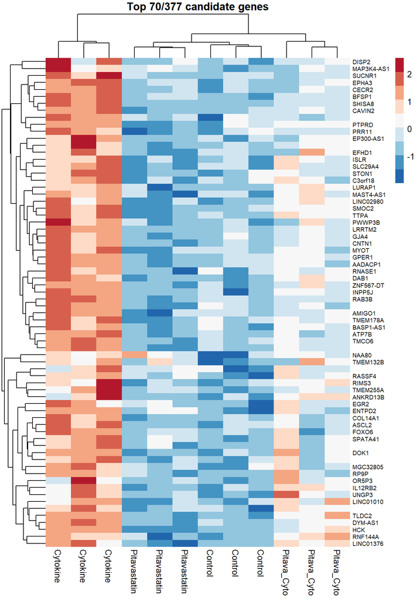

### Enrichment analysis (Over-representation analysis)

#### GOBP

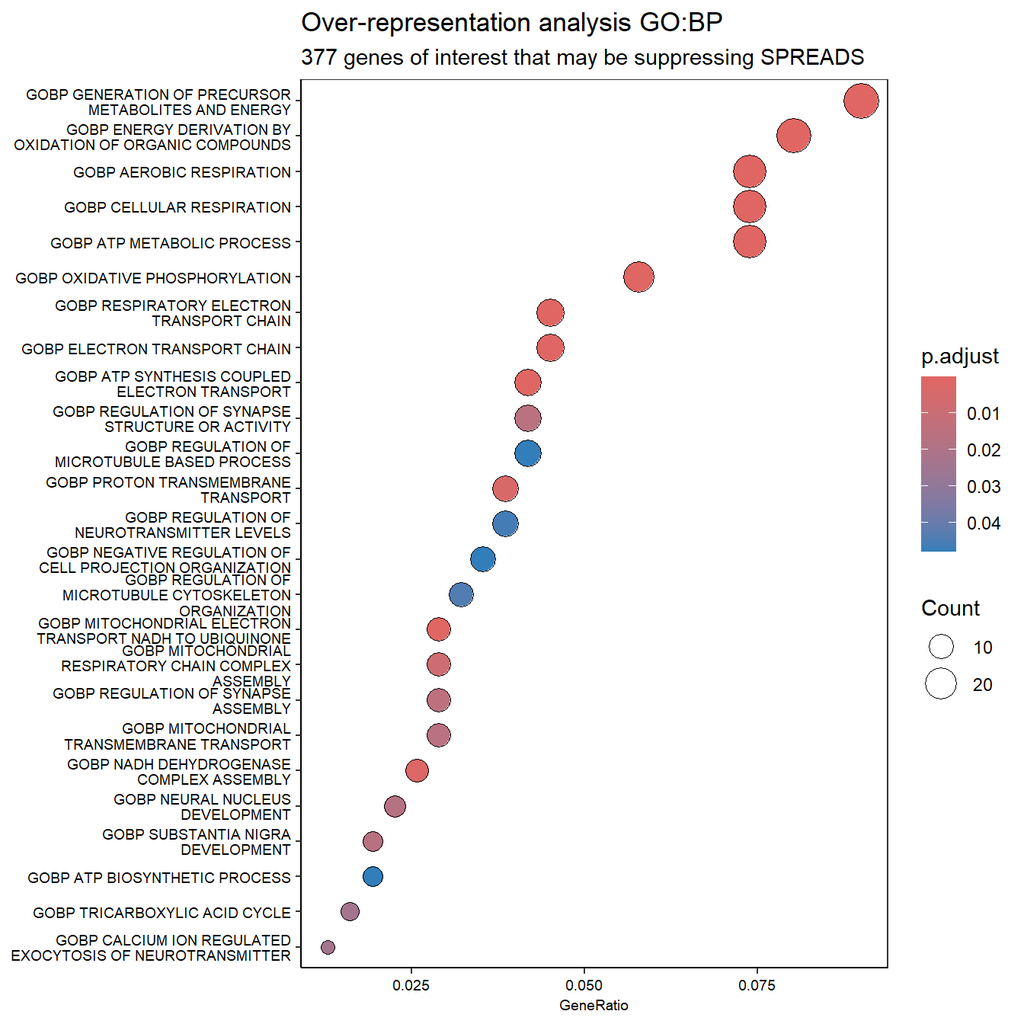

| ID | GeneRatio | BgRatio | pvalue | p.adjust | qvalue | geneID | Count |
| --- | --- | --- | --- | --- | --- | --- | --- |
| GOBP_AEROBIC_RESPIRATION | 23/311 | 187/17872 | 0.0000000 | 0.0000000 | 0.0000000 | NDUFS7/NNT/DGUOK/SUCLG1/FH/COX5A/SDHD/UQCRC2/NDUFS3/NDUFB9/COQ9/BNIP3/UQCRC1/NDUFV3/ATP5PF/SDHB/NDUFS4/NDUFA10/ATP5F1A/NDUFB10/UQCR10/ATP5PB/NDUFS1 | 23 |
| GOBP_CELLULAR_RESPIRATION | 23/311 | 231/17872 | 0.0000000 | 0.0000000 | 0.0000000 | NDUFS7/NNT/DGUOK/SUCLG1/FH/COX5A/SDHD/UQCRC2/NDUFS3/NDUFB9/COQ9/BNIP3/UQCRC1/NDUFV3/ATP5PF/SDHB/NDUFS4/NDUFA10/ATP5F1A/NDUFB10/UQCR10/ATP5PB/NDUFS1 | 23 |
| GOBP_OXIDATIVE_PHOSPHORYLATION | 18/311 | 139/17872 | 0.0000000 | 0.0000000 | 0.0000000 | NDUFS7/DGUOK/COX5A/SDHD/UQCRC2/NDUFS3/NDUFB9/COQ9/UQCRC1/NDUFV3/ATP5PF/NDUFS4/NDUFA10/ATP5F1A/NDUFB10/UQCR10/ATP5PB/NDUFS1 | 18 |
| GOBP_ENERGY_DERIVATION_BY_OXIDATION_OF_ORGANIC_COMPOUNDS | 25/311 | 321/17872 | 0.0000000 | 0.0000003 | 0.0000002 | MRAP2/NDUFS7/NNT/DGUOK/SUCLG1/FH/COX5A/SDHD/UQCRC2/NDUFS3/NR1D1/NDUFB9/COQ9/BNIP3/UQCRC1/NDUFV3/ATP5PF/SDHB/NDUFS4/NDUFA10/ATP5F1A/NDUFB10/UQCR10/ATP5PB/NDUFS1 | 25 |
| GOBP_ATP_METABOLIC_PROCESS | 23/311 | 273/17872 | 0.0000000 | 0.0000003 | 0.0000002 | NDUFS7/ALDOA/DGUOK/NMNAT1/COX5A/SDHD/UQCRC2/NDUFS3/NDUFB9/COQ9/UQCRC1/NDUFV3/ATP5PF/NDUFS4/NDUFA10/ARNT/ATP5F1A/NDUFB10/UQCR10/ATP5PB/GAPDH/ATP6V1A/NDUFS1 | 23 |
| GOBP_ATP_SYNTHESIS_COUPLED_ELECTRON_TRANSPORT | 13/311 | 92/17872 | 0.0000000 | 0.0000030 | 0.0000028 | NDUFS7/DGUOK/COX5A/SDHD/NDUFS3/NDUFB9/COQ9/NDUFV3/NDUFS4/NDUFA10/NDUFB10/UQCR10/NDUFS1 | 13 |
| GOBP_RESPIRATORY_ELECTRON_TRANSPORT_CHAIN | 14/311 | 113/17872 | 0.0000000 | 0.0000038 | 0.0000036 | NDUFS7/DGUOK/COX5A/SDHD/NDUFS3/NDUFB9/COQ9/NDUFV3/SDHB/NDUFS4/NDUFA10/NDUFB10/UQCR10/NDUFS1 | 14 |
| GOBP_GENERATION_OF_PRECURSOR_METABOLITES_AND_ENERGY | 28/311 | 494/17872 | 0.0000000 | 0.0000150 | 0.0000142 | MRAP2/NDUFS7/NNT/ALDOA/DGUOK/SUCLG1/FH/COX5A/SDHD/UQCRC2/NDUFS3/NR1D1/NDUFB9/COQ9/BNIP3/UQCRC1/NDUFV3/ATP5PF/SDHB/NDUFS4/NDUFA10/ARNT/ATP5F1A/NDUFB10/UQCR10/ATP5PB/GAPDH/NDUFS1 | 28 |
| GOBP_MITOCHONDRIAL_ELECTRON_TRANSPORT_NADH_TO_UBIQUINONE | 9/311 | 51/17872 | 0.0000002 | 0.0000612 | 0.0000579 | NDUFS7/NDUFS3/NDUFB9/COQ9/NDUFV3/NDUFS4/NDUFA10/NDUFB10/NDUFS1 | 9 |
| GOBP_ELECTRON_TRANSPORT_CHAIN | 14/311 | 167/17872 | 0.0000014 | 0.0003630 | 0.0003433 | NDUFS7/DGUOK/COX5A/SDHD/NDUFS3/NDUFB9/COQ9/NDUFV3/SDHB/NDUFS4/NDUFA10/NDUFB10/UQCR10/NDUFS1 | 14 |
| GOBP_NADH_DEHYDROGENASE_COMPLEX_ASSEMBLY | 8/311 | 58/17872 | 0.0000069 | 0.0016599 | 0.0015699 | NDUFS7/NDUFS3/NDUFB9/TIMM21/NDUFS4/NDUFA10/NDUFB10/NDUFS1 | 8 |
| GOBP_PROTON_TRANSMEMBRANE_TRANSPORT | 12/311 | 153/17872 | 0.0000154 | 0.0033984 | 0.0032141 | NDUFS7/SLC2A10/NNT/COX5A/UQCRC1/COX7B/COX6B1/ATP5PF/ATP5F1A/UQCR10/ATP5PB/ATP6V1A | 12 |
| GOBP_MITOCHONDRIAL_RESPIRATORY_CHAIN_COMPLEX_ASSEMBLY | 9/311 | 94/17872 | 0.0000379 | 0.0077034 | 0.0072857 | NDUFS7/AIFM1/NDUFS3/NDUFB9/TIMM21/NDUFS4/NDUFA10/NDUFB10/NDUFS1 | 9 |
| GOBP_REGULATION_OF_SYNAPSE_ASSEMBLY | 9/311 | 103/17872 | 0.0000781 | 0.0147249 | 0.0139264 | LRRTM2/AMIGO1/PTPRD/EEF2K/MDGA1/SEMA4A/LRFN3/SIX1/FARP1 | 9 |
| GOBP_MITOCHONDRIAL_TRANSMEMBRANE_TRANSPORT | 9/311 | 105/17872 | 0.0000907 | 0.0157841 | 0.0149282 | AIFM1/TIMM21/ATP5PF/VDAC1/TIMM50/MRPL18/ATP5F1A/SFXN3/ATP5PB | 9 |
| GOBP_REGULATION_OF_SYNAPSE_STRUCTURE_OR_ACTIVITY | 13/311 | 213/17872 | 0.0000957 | 0.0157841 | 0.0149282 | LRRTM2/AMIGO1/PTPRD/EEF2K/MDGA1/SEMA4A/LRFN3/SIX1/ABHD17A/PAFAH1B1/FARP1/TUBA1A/PTEN | 13 |
| GOBP_SUBSTANTIA_NIGRA_DEVELOPMENT | 6/311 | 44/17872 | 0.0001070 | 0.0166219 | 0.0157205 | CKB/NDUFS3/YWHAH/COX6B1/ATP5PF/ATP5PB | 6 |
| GOBP_NEURAL_NUCLEUS_DEVELOPMENT | 7/311 | 64/17872 | 0.0001200 | 0.0175969 | 0.0166427 | CKB/NDUFS3/YWHAH/COX6B1/ATP5PF/ATP5PB/SEC24B | 7 |
| GOBP_CALCIUM_ION_REGULATED_EXOCYTOSIS_OF_NEUROTRANSMITTER | 4/311 | 17/17872 | 0.0001790 | 0.0238998 | 0.0226038 | RIMS3/SYT5/UNC13B/ATP2A2 | 4 |
| GOBP_TRICARBOXYLIC_ACID_CYCLE | 5/311 | 31/17872 | 0.0001811 | 0.0238998 | 0.0226038 | NNT/SUCLG1/FH/SDHD/SDHB | 5 |
| GOBP_REGULATION_OF_MICROTUBULE_CYTOSKELETON_ORGANIZATION | 10/311 | 153/17872 | 0.0003531 | 0.0443886 | 0.0419816 | EPHA3/INPP5J/TPPP/FKBP4/SKA2/CKAP5/TBCD/PAFAH1B1/CIB1/PDCD6IP | 10 |
| GOBP_REGULATION_OF_NEUROTRANSMITTER_LEVELS | 12/311 | 214/17872 | 0.0003847 | 0.0461657 | 0.0436623 | SLC29A4/GPER1/RAB3B/RIMS3/SYT5/ALDH9A1/VAMP2/STX2/UNC13B/SNAP29/ATP2A2/SLC44A4 | 12 |
| GOBP_REGULATION_OF_MICROTUBULE_BASED_PROCESS | 13/311 | 249/17872 | 0.0004414 | 0.0480863 | 0.0454788 | EPHA3/INPP5J/XRCC3/TPPP/FKBP4/SKA2/CKAP5/TBCD/LAMP1/DNAH11/PAFAH1B1/CIB1/PDCD6IP | 13 |
| GOBP_NEGATIVE_REGULATION_OF_CELL_PROJECTION_ORGANIZATION | 11/311 | 187/17872 | 0.0004475 | 0.0480863 | 0.0454788 | DAB1/INPP5J/KREMEN1/SEMA4A/DGUOK/ARPIN/YWHAH/FKBP4/PAFAH1B1/CIB1/PTEN | 11 |
| GOBP_ATP_BIOSYNTHETIC_PROCESS | 6/311 | 57/17872 | 0.0004554 | 0.0480863 | 0.0454788 | ALDOA/DGUOK/ATP5PF/ATP5F1A/ATP5PB/ATP6V1A | 6 |

#### GOMF

[figure not shown]

| ID | GeneRatio | BgRatio | pvalue | p.adjust | qvalue | geneID | Count |
| --- | --- | --- | --- | --- | --- | --- | --- |
| GOMF_OXIDOREDUCTION_DRIVEN_ACTIVE_TRANSMEMBRANE_TRANSPORTER_ACTIVITY | 14/278 | 72/15910 | 0.0000000 | 0.0000000 | 0.0000000 | NDUFS7/CYB561D1/COX5A/NDUFS3/NDUFB9/UQCRC1/COX7B/COX6B1/NDUFV3/NDUFS4/NDUFA10/NDUFB10/UQCR10/NDUFS1 | 14 |
| GOMF_PRIMARY_ACTIVE_TRANSMEMBRANE_TRANSPORTER_ACTIVITY | 18/278 | 179/15910 | 0.0000000 | 0.0000006 | 0.0000006 | ATP7B/NDUFS7/CYB561D1/COX5A/ABCC10/NDUFS3/NDUFB9/UQCRC1/COX7B/COX6B1/NDUFV3/NDUFS4/NDUFA10/NDUFB10/UQCR10/ATP6V1A/NDUFS1/ATP2A2 | 18 |
| GOMF_ELECTRON_TRANSFER_ACTIVITY | 15/278 | 125/15910 | 0.0000000 | 0.0000008 | 0.0000008 | NDUFS7/COX5A/SDHD/NDUFS3/NDUFB9/UQCRC1/COX7B/COX6B1/NDUFV3/SDHB/NDUFS4/NDUFA10/NDUFB10/UQCR10/NDUFS1 | 15 |
| GOMF_NADH_DEHYDROGENASE_ACTIVITY | 9/278 | 45/15910 | 0.0000001 | 0.0000087 | 0.0000081 | NDUFS7/AIFM1/NDUFS3/NDUFB9/NDUFV3/NDUFS4/NDUFA10/NDUFB10/NDUFS1 | 9 |
| GOMF_OXIDOREDUCTASE_ACTIVITY_ACTING_ON_NAD_P_H | 11/278 | 88/15910 | 0.0000004 | 0.0000380 | 0.0000351 | NDUFS7/NNT/AIFM1/NDUFS3/NDUFB9/NDUFV3/CYB5R2/NDUFS4/NDUFA10/NDUFB10/NDUFS1 | 11 |
| GOMF_ACTIVE_TRANSMEMBRANE_TRANSPORTER_ACTIVITY | 22/278 | 406/15910 | 0.0000028 | 0.0002413 | 0.0002233 | SLC29A4/ATP7B/NDUFS7/SLC2A10/SLC35D1/CYB561D1/COX5A/ABCC10/NDUFS3/NDUFB9/UQCRC1/COX7B/COX6B1/NDUFV3/SLC25A11/NDUFS4/NDUFA10/NDUFB10/UQCR10/ATP6V1A/NDUFS1/ATP2A2 | 22 |
| GOMF_OXIDOREDUCTASE_ACTIVITY_ACTING_ON_NAD_P_H_QUINONE_OR_SIMILAR_COMPOUND_AS_ACCEPTOR | 8/278 | 57/15910 | 0.0000062 | 0.0004532 | 0.0004194 | NDUFS7/NDUFS3/NDUFB9/NDUFV3/NDUFS4/NDUFA10/NDUFB10/NDUFS1 | 8 |
| GOMF_PROTON_TRANSMEMBRANE_TRANSPORTER_ACTIVITY | 11/278 | 129/15910 | 0.0000163 | 0.0010482 | 0.0009700 | SLC2A10/NNT/COX5A/UQCRC1/COX7B/COX6B1/ATP5PF/ATP5F1A/UQCR10/ATP5PB/ATP6V1A | 11 |
| GOMF_PROTON_TRANSPORTING_ATP_SYNTHASE_ACTIVITY_ROTATIONAL_MECHANISM | 4/278 | 17/15910 | 0.0001814 | 0.0103421 | 0.0095707 | ATP5PF/ATP5F1A/ATP5PB/ATP6V1A | 4 |
| GOMF_PROTON_CHANNEL_ACTIVITY | 4/278 | 24/15910 | 0.0007357 | 0.0377423 | 0.0349272 | ATP5PF/ATP5F1A/ATP5PB/ATP6V1A | 4 |

## COMBINE the UP in cytokine with DOWN and UNCHANGED in double treatment

| ensembl | log2FoldChange | protID | gene | description | padj |
| --- | --- | --- | --- | --- | --- |
| ENSG00000127324 | 0.7722139 | P19075 | TSPAN8 | tetraspanin 8 [Source:HGNC Symbol;Acc:HGNC:11855] | 0.0000034 |
| ENSG00000204389 | 0.4229179 | P0DMV8 | HSPA1A | heat shock protein family A (Hsp70) member 1A [Source:HGNC Symbol;Acc:HGNC:5232] | 0.0000052 |
| ENSG00000204388 | 0.3292206 | P0DMV9 | HSPA1B | heat shock protein family A (Hsp70) member 1B [Source:HGNC Symbol;Acc:HGNC:5233] | 0.0001072 |
| ENSG00000111684 | 0.3140090 | Q6P1A2 | LPCAT3 | lysophosphatidylcholine acyltransferase 3 [Source:HGNC Symbol;Acc:HGNC:30244] | 0.0004849 |
| ENSG00000105655 | 0.2977650 | J3QRY0 | ISYNA1 | inositol-3-phosphate synthase 1 [Source:HGNC Symbol;Acc:HGNC:29821] | 0.0299998 |
| ENSG00000143416 | 0.2839050 | F8WBA9 | SELENBP1 | selenium binding protein 1 [Source:HGNC Symbol;Acc:HGNC:10719] | 0.0003274 |
| ENSG00000174844 | 0.2440909 | E9PG32 | DNAH12 | dynein axonemal heavy chain 12 [Source:HGNC Symbol;Acc:HGNC:2943] | 0.0183313 |
| ENSG00000120885 | 0.2417066 | E5RG36 | CLU | clusterin [Source:HGNC Symbol;Acc:HGNC:2095] | 0.0013359 |
| ENSG00000165698 | 0.2294103 | Q96E40 | SPACA9 | sperm acrosome associated 9 [Source:HGNC Symbol;Acc:HGNC:1367] | 0.0046370 |
| ENSG00000112584 | 0.1857274 | Q96EK7 | FAM120B | family with sequence similarity 120B [Source:HGNC Symbol;Acc:HGNC:21109] | 0.0147811 |
| ENSG00000188229 | 0.1841673 | P68371 | TUBB4B | tubulin beta 4B class IVb [Source:HGNC Symbol;Acc:HGNC:20771] | 0.0120342 |
| ENSG00000234965 | 2.9034690 | B8ZZ34 | SHISA8 | shisa family member 8 [Source:HGNC Symbol;Acc:HGNC:18351] | 0.0000002 |
| ENSG00000146006 | 2.8039319 | O43300 | LRRTM2 | leucine rich repeat transmembrane neuronal 2 [Source:HGNC Symbol;Acc:HGNC:19409] | 0.0003391 |
| ENSG00000189419 | 2.6545030 |  | SPATA41 | spermatogenesis associated 41 [Source:HGNC Symbol;Acc:HGNC:48613] | 0.0029718 |
| ENSG00000198829 | 2.5525704 | Q9BXA5 | SUCNR1 | succinate receptor 1 [Source:HGNC Symbol;Acc:HGNC:4542] | 0.0000386 |
| ENSG00000237167 | 2.3959842 |  |  | novel transcript | 0.0003454 |
| ENSG00000187513 | 2.3313381 | P35212 | GJA4 | gap junction protein alpha 4 [Source:HGNC Symbol;Acc:HGNC:4278] | 0.0110205 |
| ENSG00000182334 | 2.2463064 | Q8WZ94 | OR5P3 | olfactory receptor family 5 subfamily P member 3 [Source:HGNC Symbol;Acc:HGNC:14784] | 0.0174610 |
| ENSG00000236700 | 2.0748350 |  | LINC01010 | long intergenic non-protein coding RNA 1010 [Source:HGNC Symbol;Acc:HGNC:48978] | 0.0199376 |
| ENSG00000044524 | 2.0700728 | C9JXA2 | EPHA3 | EPH receptor A3 [Source:HGNC Symbol;Acc:HGNC:3387] | 0.0005591 |
| ENSG00000112562 | 1.9882099 | Q9H3U7 | SMOC2 | SPARC related modular calcium binding 2 [Source:HGNC Symbol;Acc:HGNC:20323] | 0.0019489 |
| ENSG00000264269 | 1.8644909 |  | DYM-AS1 | DYM antisense RNA 1 [Source:HGNC Symbol;Acc:HGNC:37046] | 0.0071892 |
| ENSG00000137561 | 1.8424202 | P49638 | TTPA | alpha tocopherol transfer protein [Source:HGNC Symbol;Acc:HGNC:12404] | 0.0004462 |
| ENSG00000187955 | 1.8412650 | Q05707 | COL14A1 | collagen type XIV alpha 1 chain [Source:HGNC Symbol;Acc:HGNC:2191] | 0.0303451 |
| ENSG00000081985 | 1.8232459 | A0A8Q3SIS8 | IL12RB2 | interleukin 12 receptor subunit beta 2 [Source:HGNC Symbol;Acc:HGNC:5972] | 0.0318911 |
| ENSG00000270343 | 1.8220700 |  | UNGP3 | uracil-DNA glycosylase pseudogene 3 [Source:HGNC Symbol;Acc:HGNC:20036] | 0.0295342 |
| ENSG00000286811 | 1.8104343 |  |  | novel transcript | 0.0417857 |
| ENSG00000120729 | 1.6620292 | B4DT68 | MYOT | myotilin [Source:HGNC Symbol;Acc:HGNC:12399] | 0.0428383 |
| ENSG00000115325 | 1.5526884 | Q99704 | DOK1 | docking protein 1 [Source:HGNC Symbol;Acc:HGNC:2990] | 0.0018261 |
| ENSG00000101342 | 1.5383863 | A0PJX2 | TLDC2 | TBC/LysM-associated domain containing 2 [Source:HGNC Symbol;Acc:HGNC:16112] | 0.0095130 |

[output cut: 358 more lines]

#### GOBP

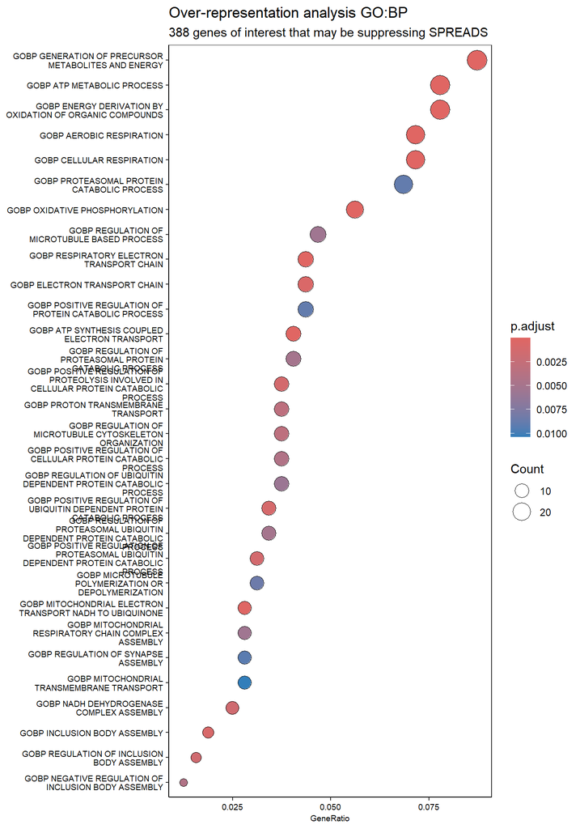

| ID | GeneRatio | BgRatio | pvalue | p.adjust | qvalue | geneID | Count |
| --- | --- | --- | --- | --- | --- | --- | --- |
| GOBP_AEROBIC_RESPIRATION | 23/321 | 187/17872 | 0.0000000 | 0.0000000 | 0.0000000 | NDUFS7/NNT/DGUOK/SUCLG1/FH/COX5A/SDHD/UQCRC2/NDUFS3/NDUFB9/COQ9/BNIP3/UQCRC1/NDUFV3/ATP5PF/SDHB/NDUFS4/NDUFA10/ATP5F1A/NDUFB10/UQCR10/ATP5PB/NDUFS1 | 23 |
| GOBP_ATP_METABOLIC_PROCESS | 25/321 | 273/17872 | 0.0000000 | 0.0000000 | 0.0000000 | HSPA1A/HSPA1B/NDUFS7/ALDOA/DGUOK/NMNAT1/COX5A/SDHD/UQCRC2/NDUFS3/NDUFB9/COQ9/UQCRC1/NDUFV3/ATP5PF/NDUFS4/NDUFA10/ARNT/ATP5F1A/NDUFB10/UQCR10/ATP5PB/GAPDH/ATP6V1A/NDUFS1 | 25 |
| GOBP_CELLULAR_RESPIRATION | 23/321 | 231/17872 | 0.0000000 | 0.0000000 | 0.0000000 | NDUFS7/NNT/DGUOK/SUCLG1/FH/COX5A/SDHD/UQCRC2/NDUFS3/NDUFB9/COQ9/BNIP3/UQCRC1/NDUFV3/ATP5PF/SDHB/NDUFS4/NDUFA10/ATP5F1A/NDUFB10/UQCR10/ATP5PB/NDUFS1 | 23 |
| GOBP_OXIDATIVE_PHOSPHORYLATION | 18/321 | 139/17872 | 0.0000000 | 0.0000000 | 0.0000000 | NDUFS7/DGUOK/COX5A/SDHD/UQCRC2/NDUFS3/NDUFB9/COQ9/UQCRC1/NDUFV3/ATP5PF/NDUFS4/NDUFA10/ATP5F1A/NDUFB10/UQCR10/ATP5PB/NDUFS1 | 18 |
| GOBP_ENERGY_DERIVATION_BY_OXIDATION_OF_ORGANIC_COMPOUNDS | 25/321 | 321/17872 | 0.0000000 | 0.0000005 | 0.0000004 | MRAP2/NDUFS7/NNT/DGUOK/SUCLG1/FH/COX5A/SDHD/UQCRC2/NDUFS3/NR1D1/NDUFB9/COQ9/BNIP3/UQCRC1/NDUFV3/ATP5PF/SDHB/NDUFS4/NDUFA10/ATP5F1A/NDUFB10/UQCR10/ATP5PB/NDUFS1 | 25 |
| GOBP_ATP_SYNTHESIS_COUPLED_ELECTRON_TRANSPORT | 13/321 | 92/17872 | 0.0000000 | 0.0000045 | 0.0000042 | NDUFS7/DGUOK/COX5A/SDHD/NDUFS3/NDUFB9/COQ9/NDUFV3/NDUFS4/NDUFA10/NDUFB10/UQCR10/NDUFS1 | 13 |
| GOBP_RESPIRATORY_ELECTRON_TRANSPORT_CHAIN | 14/321 | 113/17872 | 0.0000000 | 0.0000059 | 0.0000054 | NDUFS7/DGUOK/COX5A/SDHD/NDUFS3/NDUFB9/COQ9/NDUFV3/SDHB/NDUFS4/NDUFA10/NDUFB10/UQCR10/NDUFS1 | 14 |
| GOBP_GENERATION_OF_PRECURSOR_METABOLITES_AND_ENERGY | 28/321 | 494/17872 | 0.0000001 | 0.0000299 | 0.0000278 | MRAP2/NDUFS7/NNT/ALDOA/DGUOK/SUCLG1/FH/COX5A/SDHD/UQCRC2/NDUFS3/NR1D1/NDUFB9/COQ9/BNIP3/UQCRC1/NDUFV3/ATP5PF/SDHB/NDUFS4/NDUFA10/ARNT/ATP5F1A/NDUFB10/UQCR10/ATP5PB/GAPDH/NDUFS1 | 28 |
| GOBP_MITOCHONDRIAL_ELECTRON_TRANSPORT_NADH_TO_UBIQUINONE | 9/321 | 51/17872 | 0.0000003 | 0.0000818 | 0.0000760 | NDUFS7/NDUFS3/NDUFB9/COQ9/NDUFV3/NDUFS4/NDUFA10/NDUFB10/NDUFS1 | 9 |
| GOBP_ELECTRON_TRANSPORT_CHAIN | 14/321 | 167/17872 | 0.0000020 | 0.0005385 | 0.0005005 | NDUFS7/DGUOK/COX5A/SDHD/NDUFS3/NDUFB9/COQ9/NDUFV3/SDHB/NDUFS4/NDUFA10/NDUFB10/UQCR10/NDUFS1 | 14 |
| GOBP_INCLUSION_BODY_ASSEMBLY | 6/321 | 24/17872 | 0.0000033 | 0.0008057 | 0.0007489 | HSPA1A/HSPA1B/CLU/BAG3/DNAJB2/DNAJB1 | 6 |
| GOBP_POSITIVE_REGULATION_OF_UBIQUITIN_DEPENDENT_PROTEIN_CATABOLIC_PROCESS | 11/321 | 110/17872 | 0.0000046 | 0.0010436 | 0.0009700 | HSPA1A/HSPA1B/CLU/RNF144A/STUB1/PABIR1/ARIH1/RNF14/DNAJB2/SOCS4/PTEN | 11 |
| GOBP_POSITIVE_REGULATION_OF_PROTEOLYSIS_INVOLVED_IN_CELLULAR_PROTEIN_CATABOLIC_PROCESS | 12/321 | 135/17872 | 0.0000059 | 0.0012261 | 0.0011396 | HSPA1A/HSPA1B/CLU/RNF144A/STUB1/PABIR1/RNF40/ARIH1/RNF14/DNAJB2/SOCS4/PTEN | 12 |
| GOBP_POSITIVE_REGULATION_OF_PROTEASOMAL_UBIQUITIN_DEPENDENT_PROTEIN_CATABOLIC_PROCESS | 10/321 | 93/17872 | 0.0000066 | 0.0012665 | 0.0011771 | HSPA1A/HSPA1B/CLU/RNF144A/STUB1/PABIR1/ARIH1/RNF14/DNAJB2/SOCS4 | 10 |
| GOBP_NADH_DEHYDROGENASE_COMPLEX_ASSEMBLY | 8/321 | 58/17872 | 0.0000087 | 0.0015684 | 0.0014578 | NDUFS7/NDUFS3/NDUFB9/TIMM21/NDUFS4/NDUFA10/NDUFB10/NDUFS1 | 8 |
| GOBP_REGULATION_OF_INCLUSION_BODY_ASSEMBLY | 5/321 | 17/17872 | 0.0000094 | 0.0015845 | 0.0014727 | HSPA1A/HSPA1B/CLU/DNAJB2/DNAJB1 | 5 |
| GOBP_PROTON_TRANSMEMBRANE_TRANSPORT | 12/321 | 153/17872 | 0.0000211 | 0.0031700 | 0.0029463 | NDUFS7/SLC2A10/NNT/COX5A/UQCRC1/COX7B/COX6B1/ATP5PF/ATP5F1A/UQCR10/ATP5PB/ATP6V1A | 12 |
| GOBP_REGULATION_OF_MICROTUBULE_CYTOSKELETON_ORGANIZATION | 12/321 | 153/17872 | 0.0000211 | 0.0031700 | 0.0029463 | HSPA1A/HSPA1B/EPHA3/INPP5J/TPPP/FKBP4/SKA2/CKAP5/TBCD/PAFAH1B1/CIB1/PDCD6IP | 12 |
| GOBP_POSITIVE_REGULATION_OF_CELLULAR_PROTEIN_CATABOLIC_PROCESS | 12/321 | 158/17872 | 0.0000291 | 0.0041190 | 0.0038283 | HSPA1A/HSPA1B/CLU/RNF144A/STUB1/PABIR1/RNF40/ARIH1/RNF14/DNAJB2/SOCS4/PTEN | 12 |
| GOBP_NEGATIVE_REGULATION_OF_INCLUSION_BODY_ASSEMBLY | 4/321 | 11/17872 | 0.0000305 | 0.0041190 | 0.0038283 | HSPA1A/HSPA1B/DNAJB2/DNAJB1 | 4 |
| GOBP_REGULATION_OF_PROTEASOMAL_UBIQUITIN_DEPENDENT_PROTEIN_CATABOLIC_PROCESS | 11/321 | 138/17872 | 0.0000401 | 0.0050250 | 0.0046704 | HSPA1A/HSPA1B/CLU/RNF144A/STUB1/HSP90AB1/PABIR1/ARIH1/RNF14/DNAJB2/SOCS4 | 11 |
| GOBP_REGULATION_OF_PROTEASOMAL_PROTEIN_CATABOLIC_PROCESS | 13/321 | 190/17872 | 0.0000409 | 0.0050250 | 0.0046704 | HSPA1A/HSPA1B/CLU/RNF144A/STUB1/HSP90AB1/PABIR1/UBB/RNF40/ARIH1/RNF14/DNAJB2/SOCS4 | 13 |
| GOBP_REGULATION_OF_MICROTUBULE_BASED_PROCESS | 15/321 | 249/17872 | 0.0000469 | 0.0054554 | 0.0050704 | HSPA1A/HSPA1B/EPHA3/INPP5J/XRCC3/TPPP/FKBP4/SKA2/CKAP5/TBCD/LAMP1/DNAH11/PAFAH1B1/CIB1/PDCD6IP | 15 |
| GOBP_MITOCHONDRIAL_RESPIRATORY_CHAIN_COMPLEX_ASSEMBLY | 9/321 | 94/17872 | 0.0000485 | 0.0054554 | 0.0050704 | NDUFS7/AIFM1/NDUFS3/NDUFB9/TIMM21/NDUFS4/NDUFA10/NDUFB10/NDUFS1 | 9 |
| GOBP_REGULATION_OF_UBIQUITIN_DEPENDENT_PROTEIN_CATABOLIC_PROCESS | 12/321 | 168/17872 | 0.0000532 | 0.0057476 | 0.0053420 | HSPA1A/HSPA1B/CLU/RNF144A/STUB1/HSP90AB1/PABIR1/ARIH1/RNF14/DNAJB2/SOCS4/PTEN | 12 |
| GOBP_MICROTUBULE_POLYMERIZATION_OR_DEPOLYMERIZATION | 10/321 | 124/17872 | 0.0000813 | 0.0084406 | 0.0078450 | HSPA1A/HSPA1B/INPP5J/TPPP/FKBP4/SKA2/CKAP5/RANBP9/TBCD/CIB1 | 10 |
| GOBP_POSITIVE_REGULATION_OF_PROTEIN_CATABOLIC_PROCESS | 14/321 | 234/17872 | 0.0000900 | 0.0088804 | 0.0082538 | HSPA1A/HSPA1B/CLU/RNF144A/RHBDD3/STUB1/PABIR1/RNF40/ARIH1/RNF14/SNX1/DNAJB2/SOCS4/PTEN | 14 |
| GOBP_PROTEASOMAL_PROTEIN_CATABOLIC_PROCESS | 22/321 | 494/17872 | 0.0000921 | 0.0088804 | 0.0082538 | HSPA1A/HSPA1B/CLU/RNF144A/KBTBD6/FBXL7/UBE2S/KBTBD7/STUB1/NR1D1/HSP90AB1/PABIR1/FBXO9/MAEA/UBB/GID8/RNF40/ARIH1/RNF14/DNAJB2/SOCS4/CLOCK | 22 |
| GOBP_REGULATION_OF_SYNAPSE_ASSEMBLY | 9/321 | 103/17872 | 0.0000994 | 0.0092523 | 0.0085994 | LRRTM2/AMIGO1/PTPRD/EEF2K/MDGA1/SEMA4A/LRFN3/SIX1/FARP1 | 9 |
| GOBP_MITOCHONDRIAL_TRANSMEMBRANE_TRANSPORT | 9/321 | 105/17872 | 0.0001153 | 0.0103792 | 0.0096468 | AIFM1/TIMM21/ATP5PF/VDAC1/TIMM50/MRPL18/ATP5F1A/SFXN3/ATP5PB | 9 |
| GOBP_SUBSTANTIA_NIGRA_DEVELOPMENT | 6/321 | 44/17872 | 0.0001273 | 0.0108270 | 0.0100630 | CKB/NDUFS3/YWHAH/COX6B1/ATP5PF/ATP5PB | 6 |
| GOBP_REGULATION_OF_SYNAPSE_STRUCTURE_OR_ACTIVITY | 13/321 | 213/17872 | 0.0001311 | 0.0108270 | 0.0100630 | LRRTM2/AMIGO1/PTPRD/EEF2K/MDGA1/SEMA4A/LRFN3/SIX1/ABHD17A/PAFAH1B1/FARP1/TUBA1A/PTEN | 13 |
| GOBP_MICROTUBULE_POLYMERIZATION | 8/321 | 84/17872 | 0.0001323 | 0.0108270 | 0.0100630 | HSPA1A/HSPA1B/INPP5J/TPPP/FKBP4/CKAP5/RANBP9/TBCD | 8 |
| GOBP_RESPONSE_TO_TOPOLOGICALLY_INCORRECT_PROTEIN | 11/321 | 158/17872 | 0.0001365 | 0.0108365 | 0.0100718 | HSPA1A/HSPA1B/CLU/KBTBD6/STUB1/HSP90AB1/BAG3/VAPB/AGR2/DNAJB2/DNAJB1 | 11 |
| GOBP_NEURAL_NUCLEUS_DEVELOPMENT | 7/321 | 64/17872 | 0.0001459 | 0.0109684 | 0.0101944 | CKB/NDUFS3/YWHAH/COX6B1/ATP5PF/ATP5PB/SEC24B | 7 |
| GOBP_REGULATION_OF_PROTEIN_MODIFICATION_BY_SMALL_PROTEIN_CONJUGATION_OR_REMOVAL | 14/321 | 245/17872 | 0.0001462 | 0.0109684 | 0.0101944 | HSPA1A/HSPA1B/UBE2S/SIRT7/STUB1/TSPYL5/HSP90AB1/ARNT/UBB/RNF40/OTUB1/DNAJB2/RNF111/PTEN | 14 |
| GOBP_PROTEASOME_MEDIATED_UBIQUITIN_DEPENDENT_PROTEIN_CATABOLIC_PROCESS | 19/321 | 413/17872 | 0.0001832 | 0.0130301 | 0.0121106 | HSPA1A/HSPA1B/CLU/RNF144A/KBTBD6/FBXL7/UBE2S/KBTBD7/STUB1/HSP90AB1/PABIR1/FBXO9/MAEA/GID8/ARIH1/RNF14/DNAJB2/SOCS4/CLOCK | 19 |
| GOBP_REGULATION_OF_MICROTUBULE_POLYMERIZATION_OR_DEPOLYMERIZATION | 8/321 | 88/17872 | 0.0001834 | 0.0130301 | 0.0121106 | HSPA1A/HSPA1B/INPP5J/FKBP4/SKA2/CKAP5/TBCD/CIB1 | 8 |
| GOBP_CALCIUM_ION_REGULATED_EXOCYTOSIS_OF_NEUROTRANSMITTER | 4/321 | 17/17872 | 0.0002021 | 0.0139885 | 0.0130014 | RIMS3/SYT5/UNC13B/ATP2A2 | 4 |
| GOBP_TRICARBOXYLIC_ACID_CYCLE | 5/321 | 31/17872 | 0.0002097 | 0.0141579 | 0.0131588 | NNT/SUCLG1/FH/SDHD/SDHB | 5 |
| GOBP_REGULATION_OF_CELLULAR_PROTEIN_CATABOLIC_PROCESS | 14/321 | 258/17872 | 0.0002497 | 0.0164449 | 0.0152844 | HSPA1A/HSPA1B/CLU/RNF144A/STUB1/HSP90AB1/PABIR1/UBB/RNF40/ARIH1/RNF14/DNAJB2/SOCS4/PTEN | 14 |
| GOBP_CHAPERONE_MEDIATED_PROTEIN_FOLDING | 7/321 | 72/17872 | 0.0003062 | 0.0196827 | 0.0182938 | HSPA1A/HSPA1B/CLU/FKBP4/PEX19/DNAJB2/DNAJB1 | 7 |
| GOBP_CELLULAR_RESPONSE_TO_STEROID_HORMONE_STIMULUS | 12/321 | 203/17872 | 0.0003171 | 0.0199078 | 0.0185030 | HSPA1A/HSPA1B/GPER1/TP63/AIFM1/NR1D1/YWHAH/FKBP4/ATP5F1A/PER1/RNF14/CLOCK | 12 |
| GOBP_MICROTUBULE_NUCLEATION | 5/321 | 35/17872 | 0.0003779 | 0.0231882 | 0.0215519 | HSPA1A/HSPA1B/TPPP/CKAP5/RANBP9 | 5 |
| GOBP_REGULATION_OF_MICROTUBULE_POLYMERIZATION | 6/321 | 55/17872 | 0.0004430 | 0.0265785 | 0.0247030 | HSPA1A/HSPA1B/INPP5J/FKBP4/CKAP5/TBCD | 6 |
| GOBP_REGULATION_OF_NEUROTRANSMITTER_LEVELS | 12/321 | 214/17872 | 0.0005103 | 0.0299527 | 0.0278390 | SLC29A4/GPER1/RAB3B/RIMS3/SYT5/ALDH9A1/VAMP2/STX2/UNC13B/SNAP29/ATP2A2/SLC44A4 | 12 |
| GOBP_ATP_BIOSYNTHETIC_PROCESS | 6/321 | 57/17872 | 0.0005381 | 0.0309127 | 0.0287313 | ALDOA/DGUOK/ATP5PF/ATP5F1A/ATP5PB/ATP6V1A | 6 |
| GOBP_NEGATIVE_REGULATION_OF_CELL_PROJECTION_ORGANIZATION | 11/321 | 187/17872 | 0.0005825 | 0.0327675 | 0.0304553 | DAB1/INPP5J/KREMEN1/SEMA4A/DGUOK/ARPIN/YWHAH/FKBP4/PAFAH1B1/CIB1/PTEN | 11 |
| GOBP_REGULATION_OF_MICROTUBULE_NUCLEATION | 3/321 | 10/17872 | 0.0006272 | 0.0345625 | 0.0321236 | HSPA1A/HSPA1B/CKAP5 | 3 |
| GOBP_CHAPERONE_MEDIATED_PROTEIN_COMPLEX_ASSEMBLY | 4/321 | 23/17872 | 0.0006905 | 0.0367779 | 0.0341826 | HSPA1A/CLU/STUB1/HSP90AB1 | 4 |
| GOBP_PROTEIN_STABILIZATION | 11/321 | 191/17872 | 0.0006947 | 0.0367779 | 0.0341826 | HSPA1A/HSPA1B/CLU/PARVA/HSP90AB1/LAMP1/BAG3/GAPDH/PEX19/ATF7IP/PTEN | 11 |
| GOBP_NEGATIVE_REGULATION_OF_NEURON_PROJECTION_DEVELOPMENT | 9/321 | 136/17872 | 0.0007919 | 0.0411176 | 0.0382161 | DAB1/INPP5J/KREMEN1/SEMA4A/DGUOK/FKBP4/PAFAH1B1/CIB1/PTEN | 9 |
| GOBP_PHOSPHOLIPID_BIOSYNTHETIC_PROCESS | 13/321 | 258/17872 | 0.0008260 | 0.0419498 | 0.0389896 | LPCAT3/ISYNA1/INPP5J/PIGH/CWH43/PMVK/DOLPP1/PLAAT3/GPAA1/SOCS4/SGMS2/PTEN/SLC44A4 | 13 |
| GOBP_REGULATION_OF_PROTEIN_CATABOLIC_PROCESS | 17/321 | 395/17872 | 0.0008390 | 0.0419498 | 0.0389896 | HSPA1A/HSPA1B/CLU/RNF144A/RHBDD3/STUB1/HSP90AB1/PABIR1/ODC1/UBB/RNF40/ARIH1/RNF14/SNX1/DNAJB2/SOCS4/PTEN | 17 |
| GOBP_EXCITATORY_SYNAPSE_ASSEMBLY | 4/321 | 25/17872 | 0.0009589 | 0.0470751 | 0.0437532 | LRRTM2/PTPRD/SEMA4A/PTEN | 4 |

#### Reactome

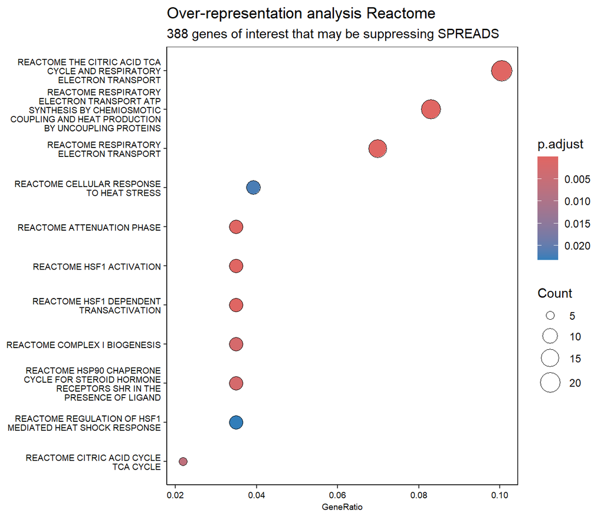

| ID | GeneRatio | BgRatio | pvalue | p.adjust | qvalue | geneID | Count |
| --- | --- | --- | --- | --- | --- | --- | --- |
| REACTOME_THE_CITRIC_ACID_TCA_CYCLE_AND_RESPIRATORY_ELECTRON_TRANSPORT | 23/229 | 178/10646 | 0.0000000 | 0.0000000 | 0.0000000 | NDUFS7/NNT/SUCLG1/FH/COX5A/SDHD/UQCRC2/NDUFS3/NDUFB9/UQCRC1/COX7B/COX6B1/NDUFV3/ATP5PF/SDHB/VDAC1/NDUFS4/NDUFA10/ATP5F1A/NDUFB10/UQCR10/ATP5PB/NDUFS1 | 23 |
| REACTOME_RESPIRATORY_ELECTRON_TRANSPORT_ATP_SYNTHESIS_BY_CHEMIOSMOTIC_COUPLING_AND_HEAT_PRODUCTION_BY_UNCOUPLING_PROTEINS | 19/229 | 127/10646 | 0.0000000 | 0.0000000 | 0.0000000 | NDUFS7/COX5A/SDHD/UQCRC2/NDUFS3/NDUFB9/UQCRC1/COX7B/COX6B1/NDUFV3/ATP5PF/SDHB/NDUFS4/NDUFA10/ATP5F1A/NDUFB10/UQCR10/ATP5PB/NDUFS1 | 19 |
| REACTOME_RESPIRATORY_ELECTRON_TRANSPORT | 16/229 | 103/10646 | 0.0000000 | 0.0000001 | 0.0000001 | NDUFS7/COX5A/SDHD/UQCRC2/NDUFS3/NDUFB9/UQCRC1/COX7B/COX6B1/NDUFV3/SDHB/NDUFS4/NDUFA10/NDUFB10/UQCR10/NDUFS1 | 16 |
| REACTOME_ATTENUATION_PHASE | 8/229 | 28/10646 | 0.0000001 | 0.0000151 | 0.0000148 | HSPA1A/HSPA1B/COL4A6/FKBP4/HSP90AB1/MRPL18/UBB/DNAJB1 | 8 |
| REACTOME_HSF1_ACTIVATION | 8/229 | 31/10646 | 0.0000002 | 0.0000290 | 0.0000284 | HSPA1A/HSPA1B/COL4A6/FKBP4/HSP90AB1/MRPL18/UBB/DNAJB1 | 8 |
| REACTOME_HSF1_DEPENDENT_TRANSACTIVATION | 8/229 | 38/10646 | 0.0000011 | 0.0001315 | 0.0001290 | HSPA1A/HSPA1B/COL4A6/FKBP4/HSP90AB1/MRPL18/UBB/DNAJB1 | 8 |
| REACTOME_COMPLEX_I_BIOGENESIS | 8/229 | 57/10646 | 0.0000270 | 0.0023440 | 0.0023003 | NDUFS7/NDUFS3/NDUFB9/NDUFV3/NDUFS4/NDUFA10/NDUFB10/NDUFS1 | 8 |
| REACTOME_HSP90_CHAPERONE_CYCLE_FOR_STEROID_HORMONE_RECEPTORS_SHR_IN_THE_PRESENCE_OF_LIGAND | 8/229 | 57/10646 | 0.0000270 | 0.0023440 | 0.0023003 | HSPA1A/HSPA1B/TUBB4B/FKBP4/STIP1/HSP90AB1/DNAJB1/TUBA1A | 8 |
| REACTOME_CITRIC_ACID_CYCLE_TCA_CYCLE | 5/229 | 22/10646 | 0.0000861 | 0.0066374 | 0.0065136 | NNT/SUCLG1/FH/SDHD/SDHB | 5 |
| REACTOME_CELLULAR_RESPONSE_TO_HEAT_STRESS | 9/229 | 101/10646 | 0.0003159 | 0.0219252 | 0.0215161 | HSPA1A/HSPA1B/COL4A6/FKBP4/HSP90AB1/MRPL18/BAG3/UBB/DNAJB1 | 9 |
| REACTOME_REGULATION_OF_HSF1_MEDIATED_HEAT_SHOCK_RESPONSE | 8/229 | 82/10646 | 0.0003676 | 0.0231916 | 0.0227589 | HSPA1A/HSPA1B/COL4A6/FKBP4/MRPL18/BAG3/UBB/DNAJB1 | 8 |

## Genes of interest

- TSPAN8: “We, therefore propose that Tspan8 contributes to tumorigenesis through enhanced ADAM17-mediated TNF α release”
- HSPA1A: “Exogenous heat shock proteins HSPA1A and HSPB1 regulate TNF-α, IL-1β and IL-10 secretion from monocytic cells”
- HSP1B: see above
- EPHA3: “We examined ERK1/2 phosphorylation in both WK1 and U251 cells and found that the ERK/MAPK pathway was more highly activated in EphA3 KD cells” “EPHA3 is upregulated by EGF in glioblastoma cells”
- SMOC2: “TGF-β1/SMOC2/AKT and ERK axis regulates proliferation, migration, and fibroblast to myofibroblast transformation in lung fibroblast, contributing with the asthma progression”
- IL12RB2: “IL12 and TNFa are two major inflammation mediators in mammals” “[IL-12-dependent activation of ERK1/2 in human T](https://pubmed.ncbi.nlm.nih.gov/19215801/) lymphoblasts”
- DOK1: “LPLI inhibits ERK phosphorylation through DOK1”
- HCK: “[Hck tyrosine kinase activity modulates tumor necrosis](https://pubmed.ncbi.nlm.nih.gov/8350043/) factor production by murine macrophages”
- EGR2: “[Novel pro-survival functions of the Kruppel-lik](https://pubmed.ncbi.nlm.nih.gov/18198176/)e transcription factor Egr2 in promotion of macrophage colony-stimulating factor-mediated osteoclast survival downstream of the MEK/ERK pathway” + “[NFκB and MAPK signalling pathways mediate TNFα](https://pubmed.ncbi.nlm.nih.gov/23485457/)-induced Early Growth Response gene transcription leading to aromatase expression”
- GPER1: “Treatment GPER1-specific agonist lead to sustained and transient activity of EGF/ERK and EGFR/AKT pathways in [2] HCC cell lines” + “[GPER negatively regulates TNFα-induced IL-6 production](https://pubmed.ncbi.nlm.nih.gov/26888479/)”

Other genes of interest, had the highest logFc in cytokine and were unchanged in pitcyt

- SHISA8: Predicted to be part of AMPA glutamate receptor complex
- LRRTM2: Regulates surface expression of AMPA receptors and instructs the development of functional glutamate release sites.

-> TNFa induces trafficking of AMPA to mb in CNS neurons

All in all our gene of interest point in

- OXPHOS-involved proteins are very up in cytokines vs double treatment
- TNFa release/production is up